# 4 ggplot2 习题答案

顶刊研习社

Li Zongzhang

2023-10-18

```r
library(tidyverse)
```

## 习题1

数据：mpg {ggplot2}

提示：mpg数据集在ggplot2这个包中，先加载ggplot2后，再运行?mpg，查看mpg的帮助文档。

注意：

在完成上述图形时，尽可能美化图形、完善坐标轴、图形标题、主题、颜色等的设置。

利用ggplot2完成以下任务：

### 1.1

1.1 任选一个定性变量，绘制条形图。

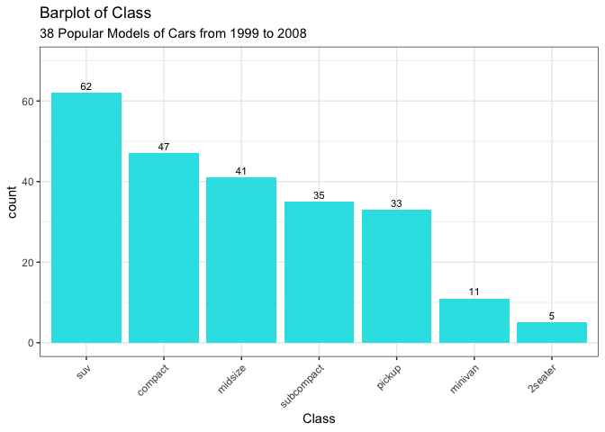

```r
mpg %>%
  ggplot(aes(fct_infreq(class))) +
  geom_bar(fill = 5) +
  geom_text(stat = "count", aes(label = after_stat(count)),
            vjust = -0.5, size = 3) +
  labs(title = "Barplot of Class",
       subtitle = "38 Popular Models of Cars from 1999 to 2008",
       x = "Class") +
  guides(x = guide_axis(angle = 45)) +
  ylim(0, 70) +
  theme_bw()
```

[figure not shown]

```r
mpg %>%
  ggplot(aes(fct_infreq(drv))) +
  geom_bar(fill = 6) +
  geom_text(stat = "count", aes(label = after_stat(count)),
            vjust = -0.5, size = 3) +
  labs(title = "Barplot of the Type of Drive Train",
       subtitle = "38 Popular Models of Cars from 1999 to 2008",
       x = "Type of Drive Train") +
  scale_x_discrete(labels = c("Front-wheel", "Four-wheel", "Rear-wheel")) +
  ylim(0, 120) +
  theme_bw()
```

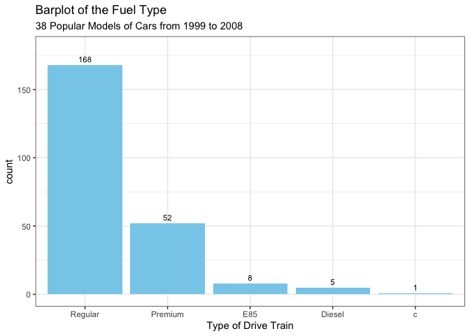

```r
# fuel type:
#   r: Regular Gasoline 85~87
#   p: Premium Gasoline  91~95
#   e: E85 85% ethanol乙醇 and 15% gasoline汽油
#   d: Diesel
#   c: ?

mpg %>%
    ggplot(aes(fct_infreq(fl))) +
  geom_bar(fill = "skyblue")+
  geom_text(stat = "count", aes(label = after_stat(count)),
            vjust = -0.5, size = 3) +
  labs(title = "Barplot of the Fuel Type",
       subtitle = "38 Popular Models of Cars from 1999 to 2008",
       x = "Type of Drive Train")+
  scale_x_discrete(labels = c("Regular", "Premium", "E85",
                              "Diesel", "c")) +
  ylim(0, 180) +
  theme_bw()
```

### 1.2

1.2 任选两个定性变量，绘制分组条形图。

簇状条形 clustered bar graph

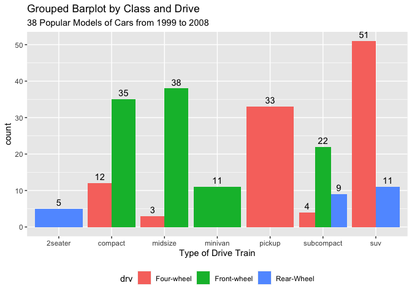

```r
# 使用ggplot2默认色系
mpg %>%
  ggplot(aes(class, fill = drv)) +
  geom_bar(position = "dodge") +
  labs(title = "Grouped Barplot by Class and Drive",
       subtitle = "38 Popular Models of Cars from 1999 to 2008",
       x = "Type of Drive Train") +
  geom_text(stat = "count",
            aes(label = after_stat(count)),
            position = position_dodge(width = 0.9), vjust = -0.5) +
  scale_fill_discrete(label = c("Four-wheel",
                                "Front-wheel",
                                "Rear-Wheel")) +
  theme(legend.position = "bottom")
```

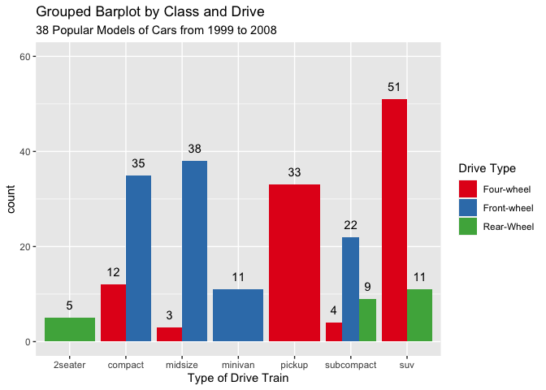

```r
# 自定义色系

# install.packages("RColorBrewer")
library(RColorBrewer) #brewer.pal()函数属于包RColorBrewer


mpg %>%
  ggplot(aes(class, fill = drv)) +
  geom_bar(position = "dodge") +
  labs(title = "Grouped Barplot by Class and Drive",
       subtitle = "38 Popular Models of Cars from 1999 to 2008",
       x = "Type of Drive Train") +
  geom_text(stat = "count", aes(label = after_stat(count)),
            position = position_dodge(width = 0.9), vjust = - 1) +
  ylim(0, 60) +
  scale_fill_brewer(palette = "Set1") +
  scale_fill_manual(values = brewer.pal(3, "Set1"),
                    name = "Drive Type",
                    labels = c("Four-wheel", "Front-wheel", "Rear-Wheel"))
```

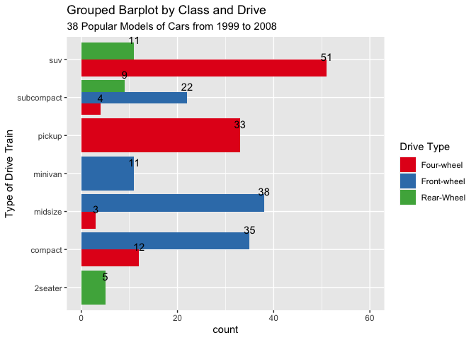

```r
library(RColorBrewer) #brewer.pal()函数属于包RColorBrewer
mpg %>%
  ggplot(aes(class, fill = drv)) +
  geom_bar(position = "dodge") +
  labs(title = "Grouped Barplot by Class and Drive",
       subtitle = "38 Popular Models of Cars from 1999 to 2008",
       x = "Type of Drive Train") +
  geom_text(stat = "count", aes(label = after_stat(count)),
            position = position_dodge(width = 0.9), vjust = - 1) +
  ylim(0, 60) +
  scale_fill_brewer(palette = "Set1") +
  scale_fill_manual(values = brewer.pal(3, "Set1"),
                    name = "Drive Type",
                    labels = c("Four-wheel", "Front-wheel", "Rear-Wheel")) +
  coord_flip()
```

堆栈条形 stacked bar graph

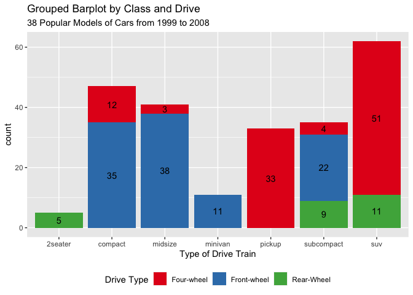

```r
#频数堆栈条形图
mpg %>%
  ggplot(aes(class, fill = drv)) +
  geom_bar(position = "stack") + #堆栈
  labs(title = "Grouped Barplot by Class and Drive",
       subtitle = "38 Popular Models of Cars from 1999 to 2008",
       x = "Type of Drive Train") +
  geom_text(stat = "count", aes(label = after_stat(count)),
            position = position_stack(vjust = 0.5)) +
  scale_fill_brewer(palette = "Set1") +
  scale_fill_manual(values = brewer.pal(3, "Set1"),
                    name = "Drive Type",
                    labels = c("Four-wheel", "Front-wheel", "Rear-Wheel")) +
  theme(legend.position = "bottom")
```

### 1.3 1.3 任选一个定量变量，绘制直方图。

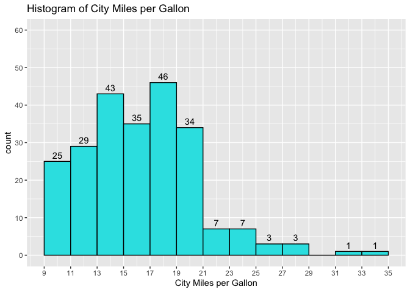

```r
mpg %>%
  ggplot(aes(cty)) +
  geom_histogram(col = 1,fill = 5, binwidth = 2) +
  stat_bin(aes(label = ifelse(after_stat(count) == 0,
                              "", after_stat(count))),
           binwidth = 2,
           geom = "text",vjust = -0.5) +
  scale_y_continuous(limits = c(0,60), breaks = seq(0,60,10)) +
  scale_x_continuous(breaks = seq(9,35,2)) +
  labs(title = "Histogram of City Miles per Gallon",
       x = "City Miles per Gallon")
```

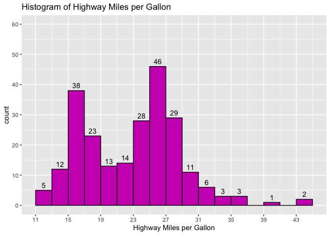

```r
mpg %>%
  ggplot(aes(hwy))  +
  geom_histogram(col = 1,fill = 6, binwidth = 2) +
  stat_bin(aes(label = ifelse(after_stat(count) == 0,
                              "", after_stat(count))),
           binwidth = 2,
           geom = "text",vjust = -0.5) +
  scale_y_continuous(limits = c(0,60), breaks = seq(0,60,10)) +
  scale_x_continuous(breaks = seq(11,45,4)) +
  labs(title = "Histogram of Highway Miles per Gallon",
       x = "Highway Miles per Gallon")
```

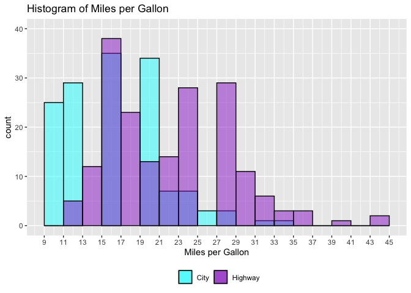

```r
# 绘制两个定量变量的直方图在同一个画布中

ggplot(mpg, aes(x = cty)) +
  geom_histogram(aes(fill = "City"), binwidth = 2,
                 color = "black", alpha = 0.5) +
  geom_histogram(aes(x = hwy, fill = "Highway"),
                 binwidth = 2, color = "black", alpha = 0.5) +
  scale_y_continuous(limits = c(0,40), breaks = seq(0,60,10))+
  scale_x_continuous(breaks = seq(9,45,2))+
  scale_fill_manual(values = c("cyan", "darkorchid"),
                    labels = c("City", "Highway"))+
  theme(legend.position = "bottom")+
  labs(title = "Histogram of Miles per Gallon",
       x = "Miles per Gallon",
       fill = "")
```

### 1.4

1.4 任选一个定量变量，两个定性变量，绘制分组直方图。

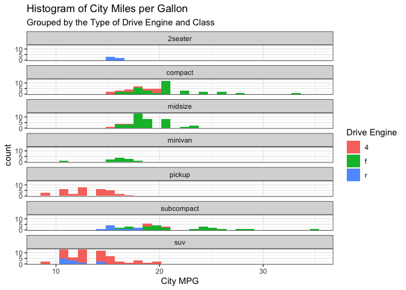

```r
mpg %>%
  ggplot(aes(cty,fill = drv))+
  geom_histogram()+
  facet_wrap(~ class, ncol = 1)+
  labs(title = "Histogram of City Miles per Gallon",
       subtitle = "Grouped by the Type of Drive Engine and Class",
       x = "City MPG",
       fill = "Drive Engine")+
  theme(legend.position = "bottom")+
  theme_bw()
```

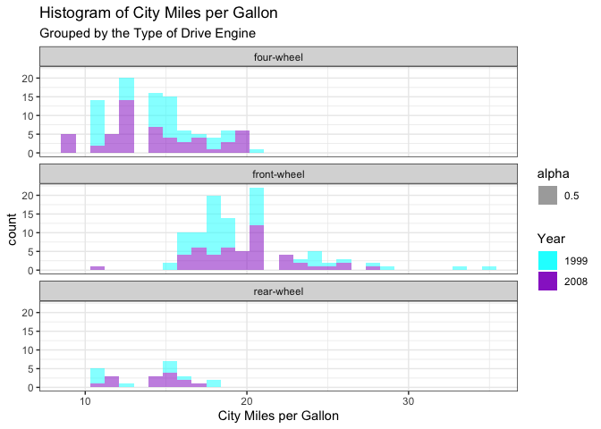

```r
mpg %>%
  ggplot(aes(cty, fill = factor(year),
             alpha = 0.5))+
  geom_histogram()+
  facet_wrap(~ drv,
             labeller = labeller(drv = c("4" = "four-wheel",
                                         "f" = "front-wheel",
                                         "r" = "rear-wheel")),
                                 ncol = 1)+
  theme_bw()+
  scale_fill_manual(values = c("cyan", "darkorchid"))+
  labs(title = "Histogram of City Miles per Gallon",
       subtitle = "Grouped by the Type of Drive Engine",
       x = "City Miles per Gallon",
       fill = "Year")
```

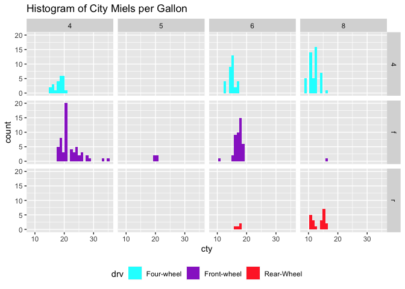

```r
mpg %>%
  ggplot(aes(cty, fill = drv))+
  geom_histogram()+
  facet_grid(rows = vars(drv),
             cols = vars(cyl))+
  scale_fill_manual(values = c("cyan", "darkorchid","firebrick1"),
                    label = c("Four-wheel",
                              "Front-wheel",
                              "Rear-Wheel"))+
  theme(legend.position = "bottom")+
  labs(title = "Histogram of City Miels per Gallon")
```

### 1.5

1.5 任选两个定量变量，绘制散点图，在散点图上添加趋势线。

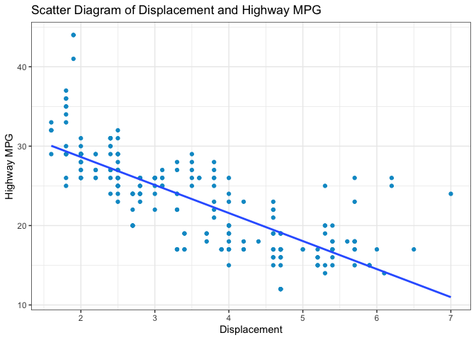

```r
mpg %>%
  ggplot(aes(displ, hwy))+
  geom_point(col = "deepskyblue3")+
  geom_smooth(method = lm, se = F)+
  labs(title = "Scatter Diagram of Displacement and Highway MPG",
       x = "Displacement",
       y = "Highway MPG")+
  theme_bw()
```

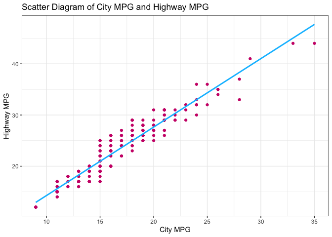

```r
mpg %>%
  ggplot(aes(cty, hwy, col = I("deeppink3")))+
  geom_point()+
  geom_smooth(method = lm, se = F, col = "deepskyblue")+
  labs(title = "Scatter Diagram of City MPG and Highway MPG",
       x = "City MPG",
       y = "Highway MPG")+
  theme_bw()
```

### 1.6

1.6 任选两个定量变量，绘制散点图，让散点的大小、颜色分别体现第3个、第4个变量的信息。

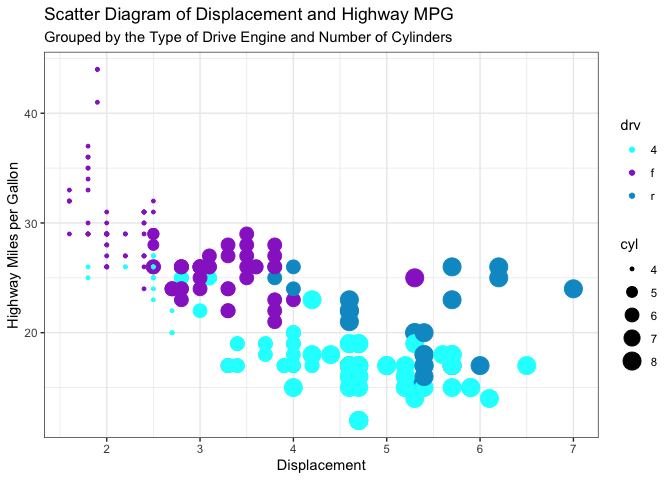

```r
mpg %>%
  ggplot(aes(displ, hwy, size = cyl, col = drv))+
  geom_point()+
  labs(title = "Scatter Diagram of Displacement and Highway MPG",
       subtitle = "Grouped by the Type of Drive Engine and Number of Cylinders",
       x = "Displacement",
       y = "Highway Miles per Gallon")+
  scale_color_manual(values = c("cyan",
                                "darkorchid",
                                "deepskyblue3"))+
  theme_bw()
```

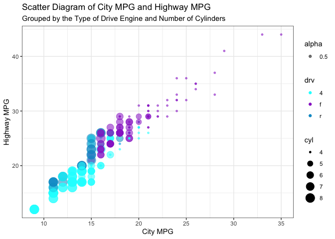

```r
mpg %>%
  ggplot(aes(cty, hwy, size = cyl, col = drv, alpha = 0.5))+
  geom_point()+
  labs(title = "Scatter Diagram of City MPG and Highway MPG",
       subtitle = "Grouped by the Type of Drive Engine and Number of Cylinders",
       x = "City MPG",
       y = "Highway MPG")+
  scale_color_manual(values = c("cyan",
                                "darkorchid",
                                "deepskyblue3"))+
  theme_bw()
```

### 1.7

1.7 任选两个定量变量，一个定性变量，绘制分组散点图，添加趋势线。

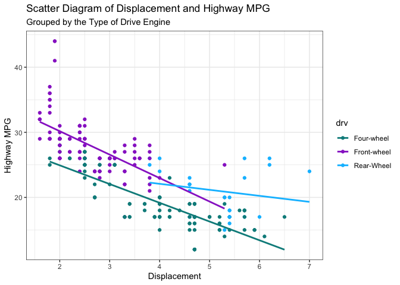

```r
mpg %>%
  ggplot(aes(displ, hwy, col =drv))+
  geom_point()+
  geom_smooth(method = lm, se = F)+
  scale_color_manual(values = c("cyan4", "darkorchid","deepskyblue"),
                    label = c("Four-wheel",
                              "Front-wheel",
                              "Rear-Wheel"))+
  labs(title = "Scatter Diagram of Displacement and Highway MPG",
       subtitle = "Grouped by the Type of Drive Engine",
       x = "Displacement",
       y = "Highway MPG")+
  theme(legend.position = "bottom")+
  theme_bw()
```

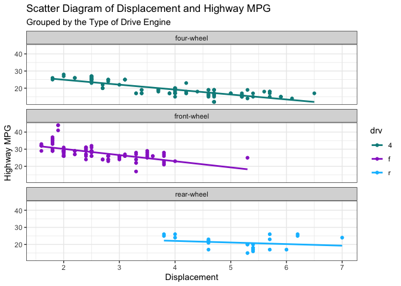

```r
mpg %>%
  ggplot(aes(displ, hwy, col = drv))+
  geom_point()+
  geom_smooth(method = lm, se = F)+
  facet_wrap(~drv, ncol = 1,
             labeller = labeller(drv = c("4" = "four-wheel",
                                         "f" = "front-wheel",
                                         "r" = "rear-wheel")))+
  scale_color_manual(values = c("cyan4", "darkorchid","deepskyblue"))+
  labs(title = "Scatter Diagram of Displacement and Highway MPG",
       subtitle = "Grouped by the Type of Drive Engine",
       x = "Displacement",
       y = "Highway MPG")+
  theme(legend.position = "bottom")+
  theme_bw()
```

### 1.8

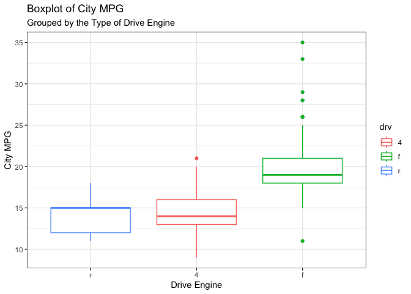

```r
mpg %>%
  ggplot(aes(reorder(drv,cty), cty,col = drv))+
  geom_boxplot() +
  labs(title = "Boxplot of City MPG",
       subtitle = "Grouped by the Type of Drive Engine",
       x = "Drive Engine",
       y = "City MPG")+
  theme_bw()
```

### 1.9

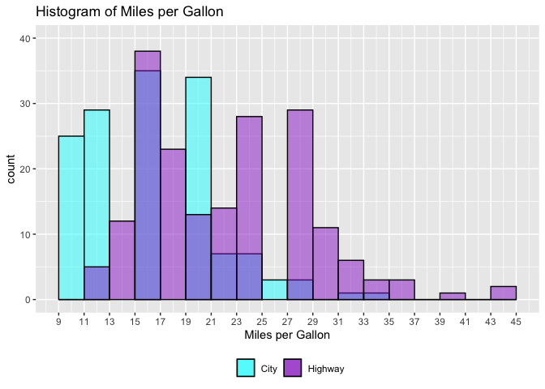

```r
# ggsave()保存最后一幅图形
# 选运行选中的图形代码，然后ggsave()


ggplot(mpg, aes(x = cty)) +
  geom_histogram(aes(fill = "City"), binwidth = 2,
                 color = "black", alpha = 0.5) +
  geom_histogram(aes(x = hwy, fill = "Highway"),
                 binwidth = 2, color = "black", alpha = 0.5) +
  scale_y_continuous(limits = c(0,40), breaks = seq(0,60,10))+
  scale_x_continuous(breaks = seq(9,45,2))+
  scale_fill_manual(values = c("cyan", "darkorchid"),
                    labels = c("City", "Highway"))+
  theme(legend.position = "bottom")+
  labs(title = "Histogram of Miles per Gallon",
       x = "Miles per Gallon",
       fill = "")
```

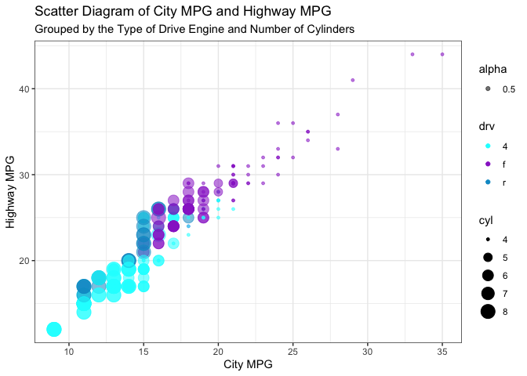

```r
ggsave("hist_cty_hwy.png", dpi = 300)


mpg %>%
  ggplot(aes(cty, hwy, size = cyl, col = drv, alpha = 0.5))+
  geom_point()+
  labs(title = "Scatter Diagram of City MPG and Highway MPG",
       subtitle = "Grouped by the Type of Drive Engine and Number of Cylinders",
       x = "City MPG",
       y = "Highway MPG")+
  scale_color_manual(values = c("cyan",
                                "darkorchid",
                                "deepskyblue3"))+
  theme_bw()
```

```r
ggsave("scat_cty_hwy.pdf", dpi = 300)
```

# 习题2

数据集：ChickWeight{datasets}

### 2.1

2.1 查看ChickWeight数据集的帮助文档，了解数据集的结构。

```r
?ChickWeight

str(ChickWeight)
```

```
Classes 'nfnGroupedData', 'nfGroupedData', 'groupedData' and 'data.frame':  578 obs. of  4 variables:
 $ weight: num  42 51 59 64 76 93 106 125 149 171 ...
 $ Time  : num  0 2 4 6 8 10 12 14 16 18 ...
 $ Chick : Ord.factor w/ 50 levels "18"<"16"<"15"<..: 15 15 15 15 15 15 15 15 15 15 ...
 $ Diet  : Factor w/ 4 levels "1","2","3","4": 1 1 1 1 1 1 1 1 1 1 ...
 - attr(*, "formula")=Class 'formula'  language weight ~ Time | Chick
  .. ..- attr(*, ".Environment")=<environment: R_EmptyEnv>
 - attr(*, "outer")=Class 'formula'  language ~Diet
  .. ..- attr(*, ".Environment")=<environment: R_EmptyEnv>
 - attr(*, "labels")=List of 2
  ..$ x: chr "Time"
  ..$ y: chr "Body weight"
 - attr(*, "units")=List of 2
  ..$ x: chr "(days)"
  ..$ y: chr "(gm)"
```

### 2.2

2.2 创建一幅线图，显示四种不同饮食下，随着时间的推移（x轴），每只小鸡的体重发展情况（y轴）。

提示：geom_line()创建线图，facet_wrap()创建子图区域。

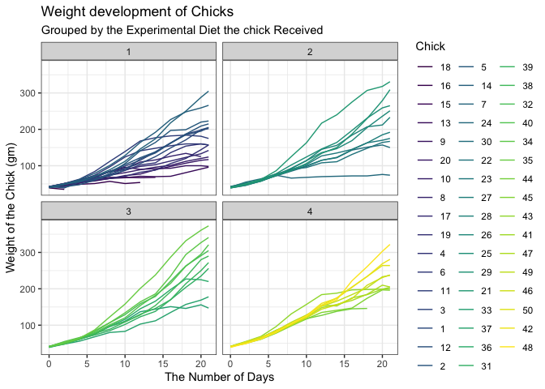

```r
data(ChickWeight)

ggplot(ChickWeight) +
  geom_line(aes(x = Time, y = weight, group = Chick, color = Chick)) +
  facet_wrap( ~ Diet) +
  labs(title = "Weight development of Chicks",
       subtitle = "Grouped by the Experimental Diet the chick Received",
       x = "The Number of Days",
       y = "Weight of the Chick (gm)") +
  theme_bw()
```